# act_report

## WeRateDogs Project

### Data Analysis and Visualization

### *Rating Distribution*

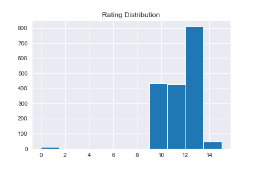

From the graph, the rating distribution is a left skewed distribution. Almost all of the ratings were betweem 9 and 14 with rating of number 12 to 13 being the highest ratings in the dataset. This is also mathematically confirmed by calculating the proportion ratings greater than 9 to the number of tweets in dataset, resulting in 0.9936452917388793 which makes up about 99% of all of the dataset.

### *Most Tweeted Dog Stages*

From *Dogtionary* (via the *WeRateDogs* books on Amazon) contains 4 terms;

1. *doggo*: A big pupper, usually older. This label does not stop a doggo from behaving like a pupper. A pupper that appears to have its life in order. Probably understands taxes and whatnot.
2. *pupper*: A small doggo, usually younger. Can be equally, if not more mature than some doggos. A doggo that is inexperienced, unfamiliar or in any way unprepared for the responsibilities asssociated with being a doggo.
3. *puppo*: A transitional phase between pupper and doggo. Easily understood as the dog equivalent of a teenager. A dog with a mixed bag of both pupper and doggo tendencies.
4. *floofer*: Any dog really. However, this label is commonly given to dogs with seemingly excess fur. Comical amounts of fur on a dog will certainly earn the dog this generic name.

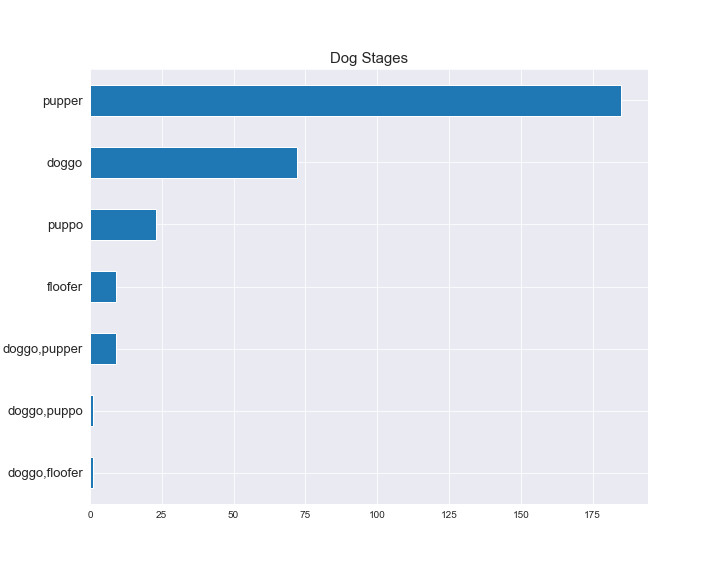

From the horizontal bar chart, *pupper* dog stages appeared to be the highest in all of the tweets, about 185 followed by *doggo*, *puppo* and floofer which are about 75, 23 and 9 respectively. The last three dog stages which are a combination of *doggo|pupper*, *doggo|puppo* and *doggo|floofer* seem to rarely be found in the tweet as seen in the bottom 3 bars in the chart.

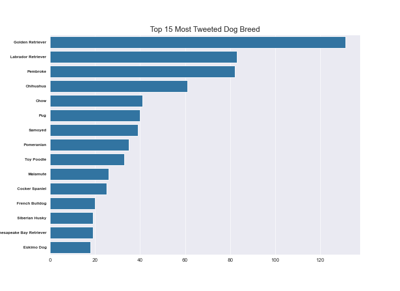

From [Wikipedia](https://en.wikipedia.org/wiki/Golden_Retriever) Golden Retrieval is a Scottish breed of retriever dog of medium size. It is characterised by a gentle and affectionate nature and a striking golden coat. It is commonly kept as a pet and is among the most frequently registered breeds in several Western countries. It is a frequent competitor in dog shows and obedience trials; it is also used as a gundog, and may be trained for use as a guide dog.

As it is the most frequently registerd breeds in Western countries, it no surprise it appeared the highest. Out of 109 number of breeds correctly predicted in the data set, the percentage number of times tweeted is 10% which is quite large considering there are 109 types of breed in the dataset.

Other type of breed which were high appeared more are *Labrador Retrieval*, *Rembroke*, *Chihuahua* and so on as shown in the chart above

### _Tweets Timeseries Trend

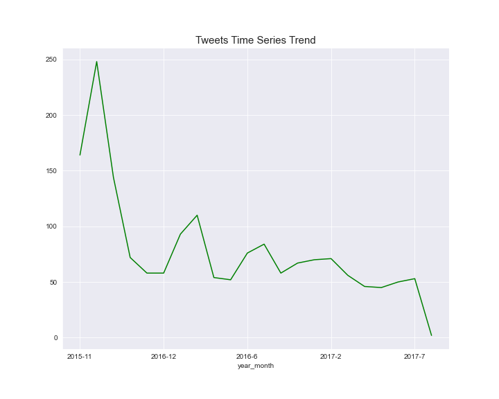

The trend line charts shows that from when [@WeRateDogs](https://twitter.com/dog_rates) started twitting their contents,November 2015 there was an uprise in number of tweets up to the highest trend point at December 2015. From then there was a downrate of number of tweets during the year 2016. There has been a flunctuation of number of tweets since 2016 up to August 2017 which is the lowest which is understandable since the dataset was extracted around that time.

### *Relationship between Retweet & Favorite count*

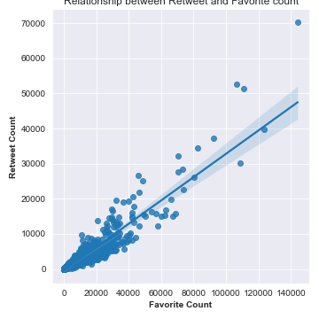

The correlation coefficient (0.92) and the linear graph shows there is strong and positive relationship between the two variables meaning that both variables move in the same direction, which simply mean the higher the likes count, the higher the retweet

### *Most Twitter User Source*

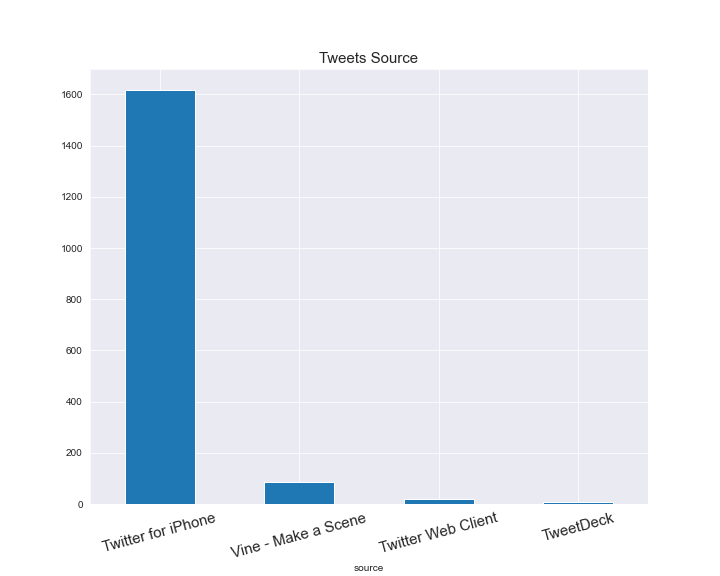

This shows that the twitter handler of @WeRateDogs mostly uses an IPhone for tweeting.